# Intrinsic-Source (Signed-Affine) Machinery

## Handover summary

> **Scope.** These results are illustrations of the intrinsic-source and signed-affine machinery only. DORM prediction is not involved.  
> **Validity floor.** $\varepsilon = 10^{-3}$.

## Notation

- $L$: number of observed source distributions.
- $m$: number of intrinsic distributions.
- $P_1,\ldots,P_L$: observed source distributions.
- $Q_1,\ldots,Q_m$: intrinsic distributions.
- $\rho=(\rho_1,\ldots,\rho_L)^\top$: signed-affine weights over the observed sources.
- $\bar r_\ell(x)$: density-ratio representation of $P_\ell$.

The weights lie on the affine hyperplane

$$\mathbf 1^\top \rho = 1.$$

The signed-affine feasible set is

$$\mathcal R
=
\left\{
\rho\in\mathbb R^L:
\mathbf 1^\top\rho=1,\quad
\sum_{\ell=1}^L \rho_\ell \bar r_\ell(x)\ge \varepsilon
\ \text{for every }x
\right\}.$$

Unlike the probability simplex, $\mathcal R$ permits negative coordinates as long as the induced mixture remains valid.

## 1. Enlarged signed-affine set and demixing recovery

This section considers two synthetic examples with known mixing matrices.

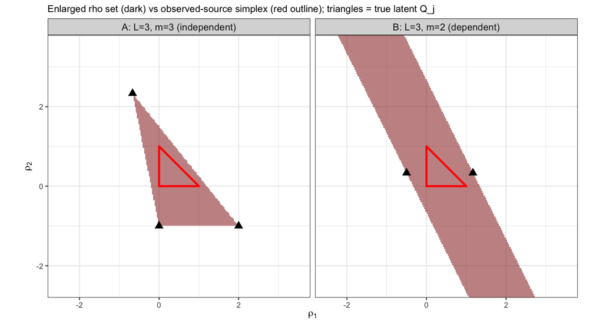

Signed-affine feasible set for $L=3$

### 1.1 Example A: $L=3$, $m=3$ — affinely independent sources

The observed distributions satisfy

$$\begin{bmatrix}
P_1\\
P_2\\
P_3
\end{bmatrix}
=
\underbrace{
\begin{bmatrix}
0.6 & 0.3 & 0.1\\
0.2 & 0.6 & 0.2\\
0.1 & 0.3 & 0.6
\end{bmatrix}
}_{\Pi}
\begin{bmatrix}
Q_1\\
Q_2\\
Q_3
\end{bmatrix}.$$

Equivalently,

$$\begin{aligned}
P_1 &= 0.6Q_1+0.3Q_2+0.1Q_3,\\
P_2 &= 0.2Q_1+0.6Q_2+0.2Q_3,\\
P_3 &= 0.1Q_1+0.3Q_2+0.6Q_3.
\end{aligned}$$

#### Geometry and recovery

| Quantity | Result |
| --- | --- |
| Area of $\mathcal R$ | $3.32$ |
| Enlargement relative to the simplex | $6.5\times$ |
| Coordinate range of $\rho$ | $[-0.98,\,2.30]$ |
| Is $\mathcal R$ bounded? | **Yes** |
| Maximum pairwise $\kappa^*$, oracle ratios | $0.0000$ |
| Maximum pairwise $\kappa^*$, estimated ratios | $0.0000$ |

Values near zero for the maximum pairwise $\kappa^*$ indicate that the recovered components are mutually irreducible.

Define the backward coefficients by

$$Q_j=\sum_{\ell=1}^L \alpha_{\ell j}P_\ell,
\qquad
\alpha=(\Pi^+)^\top,$$

where $\Pi^+$ denotes the Moore–Penrose pseudoinverse. The coefficient columns are:

| Method | Column 1 | Column 2 | Column 3 | Best-permutation Frobenius error |
| --- | --- | --- | --- | --- |
| True $(\Pi^+)^\top$ | $(2,-1,0)^\top$ | $(-0.67,2.33,-0.67)^\top$ | $(0,-1,2)^\top$ | — |
| Oracle recovery | $(-0.67,2.33,-0.67)^\top$ | $(0,-1,2)^\top$ | $(2,-1,0)^\top$ | $0.00$ |
| Estimated recovery | $(-0.30,1.60,-0.29)^\top$ | $(-0.05,-0.35,1.40)^\top$ | $(1.25,-0.64,0.39)^\top$ | $1.57$ |

The oracle procedure recovers the true columns exactly up to permutation.

### 1.2 Example B: $L=3$, $m=2$ — affinely dependent sources

The observed distributions satisfy

$$\begin{bmatrix}
P_1\\
P_2\\
P_3
\end{bmatrix}
=
\underbrace{
\begin{bmatrix}
0.8 & 0.2\\
0.5 & 0.5\\
0.2 & 0.8
\end{bmatrix}
}_{\Pi}
\begin{bmatrix}
Q_1\\
Q_2
\end{bmatrix}.$$

Equivalently,

$$\begin{aligned}
P_1 &= 0.8Q_1+0.2Q_2,\\
P_2 &= 0.5Q_1+0.5Q_2,\\
P_3 &= 0.2Q_1+0.8Q_2.
\end{aligned}$$

#### Geometry and recovery

| Quantity | Result |
| --- | --- |
| Area of the displayed portion of $\mathcal R$ | $11.74$ |
| Displayed enlargement relative to the simplex | $23.1\times$ |
| Displayed coordinate range of $\rho$ | $[-3.00,\,4.00]$ |
| Is $\mathcal R$ bounded? | **No** |
| Maximum pairwise $\kappa^*$, oracle ratios | $0.0000$ |
| Maximum pairwise $\kappa^*$, estimated ratios | $0.0000$ |

The backward coefficient columns are:

| Method | Column 1 | Column 2 | Best-permutation Frobenius error |
| --- | --- | --- | --- |
| True $(\Pi^+)^\top$ | $(1.17,0.33,-0.50)^\top$ | $(-0.50,0.33,1.17)^\top$ | — |
| Oracle recovery | $(1.33,0,-0.33)^\top$ | $(-0.33,0,1.33)^\top$ | $0.58$ |
| Estimated recovery | $(1.15,0,-0.15)^\top$ | $(-0.17,0,1.17)^\top$ | $0.67$ |

Because $m<L$, the representation of each $Q_j$ in terms of the $P_\ell$’s is not unique: coefficients may differ by a null-space direction while inducing the same distribution.

### 1.3 Main synthetic-example conclusions

1. **When $m=L=3$**, the observed sources are affinely independent. The set $\mathcal R$ is a bounded triangle approximately $6.5$ times as large as the simplex. Its corners correspond to the three latent $Q_j$’s, which lie outside the observed simplex and are therefore “purer” than any observed source. Oracle demixing recovers them exactly up to permutation.
2. **When $m=2<L=3$**, the observed sources are affinely dependent. The set $\mathcal R$ is unbounded: a null direction in the three-dimensional weight vector leaves the two-component mixture unchanged. This noncompactness is the geometric source of signed-prior instability when $L$ is large.

## 2. Demixing the real data: $L=12$ donors and $m=3,\ldots,12$

All 12 donors are used as observed sources. **The density ratio is now estimated in the Harmony embedding** (batch-corrected RNA PCA, batch = donor; RNA-only, no ADT leakage) instead of the full gene space, so shared cell-type structure is no longer masked by technical batch effects.

| $m$ | $\max_{j\neq k}\kappa^*(Q_j\mid Q_k)$ | Vertex donors | $\max_{\ell,j}\lvert\alpha_{\ell j}\rvert$ |
| --- | --- | --- | --- |
| $3$ | 0.0000 | `s1d3`, `s3d7`, `s4d8` | 2.95 |
| $4$ | 0.0000 | `s1d3`, `s3d7`, `s4d8`, `s4d9` | 3.33 |
| $5$ | 0.0000 | `s1d3`, `s2d5`, `s3d7`, `s4d8`, `s4d9` | 3.79 |
| $6$ | 0.0000 | `s1d3`, `s2d1`, `s2d5`, `s3d7`, `s4d8`, `s4d9` | 5.35 |
| $7$ | 0.0000 | `s1d3`, `s2d1`, `s2d4`, `s2d5`, `s3d7`, `s4d8`, `s4d9` | 4.40 |
| $8$ | 0.0000 | `s1d3`, `s2d1`, `s2d4`, `s2d5`, `s3d7`, `s4d1`, `s4d8`, `s4d9` | 4.83 |
| $9$ | 0.0000 | `s1d1`, `s1d3`, `s2d1`, `s2d4`, `s2d5`, `s3d7`, `s4d1`, `s4d8`, `s4d9` | 6.22 |
| $10$ | 0.0000 | `s1d1`, `s1d2`, `s1d3`, `s2d1`, `s2d4`, `s2d5`, `s3d7`, `s4d1`, `s4d8`, `s4d9` | 7.35 |
| $11$ | 0.0000 | `s1d1`, `s1d2`, `s1d3`, `s2d1`, `s2d4`, `s2d5`, `s3d6`, `s3d7`, `s4d1`, `s4d8`, `s4d9` | 8.32 |
| $12$ | 0.0000 | `s1d1`, `s1d2`, `s1d3`, `s2d1`, `s2d4`, `s2d5`, `s3d1`, `s3d6`, `s3d7`, `s4d1`, `s4d8`, `s4d9` | 7.30 |

Unlike the full-gene-space analysis (where every pair had $\kappa^*\approx0$ and 4% of pairs were reducible), in the embedding **100% of donor pairs are now mutually reducible** (mean pairwise $\kappa^*=0.518$): the sources genuinely share structure. The demixer, however, still selects individual donors as vertices $Q_j$ — it operates on the 12 donor-mixtures, so it relabels donors rather than isolating cell-type programs (which would require demixing over cells or clusters).

## 3. Affine effective dimension and forward reconstruction

### 3.1 Meaning of “affine effective dimension”

Stack the $L$ donor density-ratio vectors $\bar r_\ell$, evaluated on the pooled sample, as rows of a matrix. Center each column and compute its singular values $s_1,s_2,\ldots$.

The participation ratio is

$$\operatorname{PR}
=
\frac{\left(\sum_k s_k\right)^2}
{\sum_k s_k^2}.$$

It acts as a continuous or “soft” rank:

- $\operatorname{PR}\approx 1$ when one direction dominates;
- $\operatorname{PR}\approx d$ when approximately $d$ directions contribute comparably.

Because the observed sources lie on an affine slice of the form $\pi^\top r=1$, the maximum possible affine dimension is $L-1$.

#### Observed values (Harmony embedding)

- All $L=12$ donors: $\operatorname{PR}=5.9$ out of a maximum of 11. The singular values relative to $s_1$ are
  $$1.00,\ 0.93,\ 0.39,\ 0.34,\ 0.25,\ 0.19,\ 0.17,\ 0.12,\ 0.11,\ 0.10,\
  0.08,\ 0.00.$$
- With donor `s3d7` held out ($L=11$): $\operatorname{PR}=5.6$ out of a maximum of 10.

For comparison, in the **full gene space** these were $\operatorname{PR}=10.2/11$ and $9.2/10$ — i.e. nearly full rank. The embedding **roughly halves the affine dimension to $\approx6$**: a genuine low-dimensional latent structure now exists (consistent with the high reducibility above), whereas in the gene space there was essentially none.

### 3.2 Forward-reconstruction criterion

For each $m$, every observed source is approximated by an affine combination of the estimated intrinsic sources:

$$\widehat\Pi_{\ell\cdot}
\in
\underset{w\in\mathbb R^m}{\arg\min}
\left\|
\bar r_\ell-\sum_{j=1}^m w_j\bar Q_j
\right\|_2
\quad\text{subject to}\quad
\sum_{j=1}^m w_j=1.$$

The reported diagnostic is the relative $\ell_2$ residual. The $m$ vertex donors reconstruct almost perfectly by construction; the $L-m$ non-vertex donors are the meaningful diagnostic cases.

| $m$ | Median residual (non-vertex) | Maximum residual (non-vertex) | Non-vertex donors with residual $<0.10$ | $\min_{\ell,j}\Pi_{\ell j}$ |
| --- | --- | --- | --- | --- |
| $3$ | 0.163 | 0.252 | 0 / 9 | -0.12 |
| $4$ | 0.127 | 0.253 | 1 / 8 | -0.21 |
| $5$ | 0.109 | 0.178 | 0 / 7 | -0.32 |
| $6$ | 0.104 | 0.173 | 3 / 6 | -0.28 |
| $7$ | 0.087 | 0.169 | 3 / 5 | -0.28 |
| $8$ | 0.098 | 0.113 | 2 / 4 | -0.27 |
| $9$ | 0.081 | 0.087 | 3 / 3 | -0.27 |
| $10$ | 0.090 | 0.091 | 2 / 2 | -0.37 |
| $11$ | 0.088 | 0.088 | 1 / 1 | -0.30 |
| $12$ | — | — | 0 / 0 (all vertices) | -0.30 |

The non-vertex residuals are **lower than in the full gene space** (there the median stayed $0.7–1.0$; here it is $\approx0.10$ at $m=6$), reflecting the shared structure the embedding exposes. They are nonetheless far from zero and the forward weights still turn negative, so a small set of $Q_j$ still does not reconstruct all donors — the compression is partial, not clean.

## 4. Detailed backward and forward coefficients

The backward and forward representations are

$$Q_j=\sum_{\ell=1}^L\alpha_{\ell j}P_\ell,
\qquad
P_\ell\approx\sum_{j=1}^m\Pi_{\ell j}Q_j.$$

All coefficients below are computed in the Harmony embedding space. To keep the tables readable, $\alpha$ and $\Pi$ are separated for $m=6$ and $m=12$.

### 4.1 Results for $m=3$ (vertices: `s1d3`, `s3d7`, `s4d8`)

| Donor | Vertex | $\alpha_{\ell 1}$ | $\alpha_{\ell 2}$ | $\alpha_{\ell 3}$ | $\Pi_{\ell 1}$ | $\Pi_{\ell 2}$ | $\Pi_{\ell 3}$ | Residual |
| --- | --- | --- | --- | --- | --- | --- | --- | --- |
| `s1d1` | — | 0.00 | 0.00 | 0.00 | 0.24 | -0.06 | 0.81 | 0.14 |
| `s1d2` | — | 0.00 | 0.00 | 0.00 | 0.35 | -0.12 | 0.77 | 0.16 |
| `s1d3` | Yes | -0.76 | -1.41 | 1.11 | 0.16 | -0.08 | 0.92 | 0.03 |
| `s2d1` | — | 0.00 | 0.00 | 0.00 | 0.42 | -0.06 | 0.64 | 0.15 |
| `s2d4` | — | 0.00 | 0.00 | 0.00 | 0.31 | -0.06 | 0.75 | 0.17 |
| `s2d5` | — | 0.00 | 0.00 | 0.00 | 0.14 | 0.17 | 0.70 | 0.25 |
| `s3d1` | — | 0.00 | 0.00 | 0.00 | 0.47 | -0.04 | 0.57 | 0.12 |
| `s3d6` | — | 0.00 | 0.00 | 0.00 | 0.32 | -0.07 | 0.75 | 0.13 |
| `s3d7` | Yes | 2.02 | -0.53 | -0.42 | 0.58 | 0.00 | 0.41 | 0.03 |
| `s4d1` | — | 0.00 | 0.00 | 0.00 | 0.24 | -0.07 | 0.84 | 0.18 |
| `s4d8` | Yes | -0.26 | 2.95 | 0.31 | 0.18 | 0.30 | 0.51 | 0.02 |
| `s4d9` | — | 0.00 | 0.00 | 0.00 | 0.37 | -0.12 | 0.75 | 0.24 |

### 4.2 Results for $m=6$ (vertices: `s1d3`, `s2d1`, `s2d5`, `s3d7`, `s4d8`, `s4d9`)

#### Backward coefficients $\alpha$

| Donor | Vertex | $\alpha_{\ell 1}$ | $\alpha_{\ell 2}$ | $\alpha_{\ell 3}$ | $\alpha_{\ell 4}$ | $\alpha_{\ell 5}$ | $\alpha_{\ell 6}$ |
| --- | --- | --- | --- | --- | --- | --- | --- |
| `s1d1` | — | 0.00 | 0.00 | 0.00 | 0.00 | 0.00 | 0.00 |
| `s1d2` | — | 0.00 | 0.00 | 0.00 | 0.00 | 0.00 | 0.00 |
| `s1d3` | Yes | -1.63 | -0.51 | -0.81 | -1.77 | -1.64 | 1.75 |
| `s2d1` | Yes | 0.10 | -5.35 | -2.13 | -2.80 | 3.21 | 0.04 |
| `s2d4` | — | 0.00 | 0.00 | 0.00 | 0.00 | 0.00 | 0.00 |
| `s2d5` | Yes | -1.65 | 0.87 | 0.46 | 3.48 | 0.10 | 0.26 |
| `s3d1` | — | 0.00 | 0.00 | 0.00 | 0.00 | 0.00 | 0.00 |
| `s3d6` | — | 0.00 | 0.00 | 0.00 | 0.00 | 0.00 | 0.00 |
| `s3d7` | Yes | -1.99 | 1.50 | 2.81 | 2.35 | -0.51 | 0.57 |
| `s4d1` | — | 0.00 | 0.00 | 0.00 | 0.00 | 0.00 | 0.00 |
| `s4d8` | Yes | 4.63 | 0.17 | -0.12 | -1.39 | -0.05 | -0.69 |
| `s4d9` | Yes | 1.55 | 4.32 | 0.78 | 1.14 | -0.11 | -0.93 |

#### Forward weights $\Pi$ and reconstruction residuals

| Donor | Vertex | $\Pi_{\ell 1}$ | $\Pi_{\ell 2}$ | $\Pi_{\ell 3}$ | $\Pi_{\ell 4}$ | $\Pi_{\ell 5}$ | $\Pi_{\ell 6}$ | Residual |
| --- | --- | --- | --- | --- | --- | --- | --- | --- |
| `s1d1` | — | 0.08 | 0.14 | -0.12 | -0.04 | 0.31 | 0.62 | 0.11 |
| `s1d2` | — | 0.01 | 0.26 | -0.04 | -0.13 | 0.39 | 0.51 | 0.10 |
| `s1d3` | Yes | 0.07 | 0.17 | -0.11 | -0.04 | 0.15 | 0.76 | 0.06 |
| `s2d1` | Yes | 0.04 | 0.11 | 0.01 | -0.05 | 0.45 | 0.45 | 0.04 |
| `s2d4` | — | 0.05 | 0.16 | -0.07 | -0.03 | 0.35 | 0.54 | 0.13 |
| `s2d5` | Yes | 0.17 | 0.02 | -0.28 | 0.36 | 0.17 | 0.56 | 0.05 |
| `s3d1` | — | 0.04 | 0.08 | 0.13 | -0.07 | 0.39 | 0.43 | 0.08 |
| `s3d6` | — | 0.05 | 0.15 | -0.05 | -0.04 | 0.33 | 0.56 | 0.09 |
| `s3d7` | Yes | 0.03 | 0.02 | 0.40 | -0.07 | 0.24 | 0.38 | 0.04 |
| `s4d1` | — | 0.06 | 0.19 | -0.11 | -0.05 | 0.28 | 0.63 | 0.17 |
| `s4d8` | Yes | 0.32 | -0.05 | 0.05 | 0.11 | 0.07 | 0.49 | 0.05 |
| `s4d9` | Yes | -0.01 | 0.38 | -0.08 | -0.11 | 0.44 | 0.38 | 0.07 |

### 4.3 Results for $m=12$

Because the $m=12$ matrices are wide, each is divided into two column blocks.

#### Backward coefficients $\alpha$: columns 1–6

| Donor | Vertex | $\alpha_{\ell 1}$ | $\alpha_{\ell 2}$ | $\alpha_{\ell 3}$ | $\alpha_{\ell 4}$ | $\alpha_{\ell 5}$ | $\alpha_{\ell 6}$ |
| --- | --- | --- | --- | --- | --- | --- | --- |
| `s1d1` | Yes | -2.28 | -1.92 | -3.29 | -0.01 | -2.97 | -1.73 |
| `s1d2` | Yes | -1.22 | -5.07 | -2.97 | -2.71 | -2.53 | -0.66 |
| `s1d3` | Yes | -0.74 | -0.12 | -0.99 | -0.97 | -0.89 | 0.10 |
| `s2d1` | Yes | -2.52 | -6.72 | -4.62 | 0.05 | -5.21 | -3.27 |
| `s2d4` | Yes | -0.05 | -1.19 | -1.32 | -1.07 | -0.76 | -0.80 |
| `s2d5` | Yes | -1.18 | 0.14 | 0.59 | 0.54 | 0.21 | 0.59 |
| `s3d1` | Yes | -2.26 | 2.55 | 1.23 | -7.30 | -1.99 | 3.23 |
| `s3d6` | Yes | 2.87 | 3.99 | 2.53 | 0.46 | 7.23 | 0.18 |
| `s3d7` | Yes | 0.80 | 0.35 | 1.12 | 5.17 | 3.29 | 1.94 |
| `s4d1` | Yes | 1.48 | 1.34 | 5.24 | 2.74 | 1.84 | 0.95 |
| `s4d8` | Yes | 4.19 | 1.25 | 0.78 | 0.76 | 0.77 | -0.20 |
| `s4d9` | Yes | 1.92 | 6.40 | 2.69 | 3.33 | 2.01 | 0.67 |

#### Backward coefficients $\alpha$: columns 7–12

| Donor | Vertex | $\alpha_{\ell 7}$ | $\alpha_{\ell 8}$ | $\alpha_{\ell 9}$ | $\alpha_{\ell 10}$ | $\alpha_{\ell 11}$ | $\alpha_{\ell 12}$ |
| --- | --- | --- | --- | --- | --- | --- | --- |
| `s1d1` | Yes | -2.73 | -2.38 | -4.30 | -5.65 | -4.02 | 2.35 |
| `s1d2` | Yes | 1.27 | -0.60 | -2.41 | -3.34 | 2.56 | 0.69 |
| `s1d3` | Yes | -0.08 | -0.18 | 0.27 | 3.95 | 0.95 | -0.51 |
| `s2d1` | Yes | -6.33 | -5.58 | 3.11 | 3.67 | 1.45 | -0.06 |
| `s2d4` | Yes | -0.26 | 4.20 | 2.08 | 1.39 | 1.28 | -0.33 |
| `s2d5` | Yes | 2.93 | 1.17 | 0.65 | 1.08 | -0.04 | 0.06 |
| `s3d1` | Yes | 1.83 | 1.32 | 0.25 | 0.90 | -0.14 | 0.04 |
| `s3d6` | Yes | 1.90 | 0.74 | 0.63 | -0.48 | -0.10 | -0.37 |
| `s3d7` | Yes | 2.74 | 2.67 | -0.50 | -0.36 | -0.51 | 0.11 |
| `s4d1` | Yes | 0.22 | 0.19 | 0.34 | 0.10 | -0.22 | -0.14 |
| `s4d8` | Yes | -0.15 | -0.41 | 0.48 | -0.57 | 0.27 | -0.43 |
| `s4d9` | Yes | -0.35 | -0.15 | 0.39 | 0.32 | -0.46 | -0.41 |

#### Forward weights $\Pi$: columns 1–6

| Donor | Vertex | $\Pi_{\ell 1}$ | $\Pi_{\ell 2}$ | $\Pi_{\ell 3}$ | $\Pi_{\ell 4}$ | $\Pi_{\ell 5}$ | $\Pi_{\ell 6}$ |
| --- | --- | --- | --- | --- | --- | --- | --- |
| `s1d1` | Yes | 0.07 | 0.04 | 0.01 | -0.04 | 0.03 | -0.05 |
| `s1d2` | Yes | 0.02 | 0.05 | 0.01 | -0.02 | 0.03 | 0.02 |
| `s1d3` | Yes | 0.12 | 0.02 | 0.02 | -0.06 | 0.07 | -0.08 |
| `s2d1` | Yes | 0.02 | 0.01 | -0.03 | -0.00 | 0.05 | 0.11 |
| `s2d4` | Yes | 0.04 | 0.04 | 0.02 | -0.04 | 0.02 | -0.09 |
| `s2d5` | Yes | 0.02 | 0.06 | 0.05 | 0.01 | -0.09 | -0.26 |
| `s3d1` | Yes | 0.04 | 0.03 | -0.02 | -0.07 | 0.02 | 0.25 |
| `s3d6` | Yes | 0.02 | 0.03 | -0.01 | -0.09 | 0.19 | -0.03 |
| `s3d7` | Yes | 0.05 | -0.05 | -0.11 | 0.05 | 0.10 | 0.35 |
| `s4d1` | Yes | 0.04 | -0.05 | 0.25 | -0.04 | 0.02 | -0.05 |
| `s4d8` | Yes | 0.32 | -0.02 | -0.04 | -0.05 | -0.06 | 0.04 |
| `s4d9` | Yes | -0.05 | 0.22 | -0.04 | 0.06 | -0.02 | 0.02 |

#### Forward weights $\Pi$: columns 7–12 and residuals

| Donor | Vertex | $\Pi_{\ell 7}$ | $\Pi_{\ell 8}$ | $\Pi_{\ell 9}$ | $\Pi_{\ell 10}$ | $\Pi_{\ell 11}$ | $\Pi_{\ell 12}$ | Residual |
| --- | --- | --- | --- | --- | --- | --- | --- | --- |
| `s1d1` | Yes | -0.02 | 0.03 | -0.01 | 0.11 | 0.03 | 0.81 | 0.05 |
| `s1d2` | Yes | -0.01 | -0.02 | -0.04 | 0.01 | 0.36 | 0.59 | 0.06 |
| `s1d3` | Yes | -0.03 | 0.04 | -0.30 | 0.36 | 0.15 | 0.69 | 0.07 |
| `s2d1` | Yes | -0.05 | -0.07 | 0.18 | 0.03 | 0.14 | 0.60 | 0.05 |
| `s2d4` | Yes | -0.09 | 0.19 | 0.07 | 0.06 | 0.16 | 0.62 | 0.06 |
| `s2d5` | Yes | 0.34 | -0.09 | 0.23 | 0.08 | -0.01 | 0.67 | 0.06 |
| `s3d1` | Yes | -0.05 | -0.02 | 0.11 | 0.03 | 0.10 | 0.58 | 0.05 |
| `s3d6` | Yes | -0.02 | -0.03 | 0.06 | 0.08 | 0.14 | 0.66 | 0.06 |
| `s3d7` | Yes | -0.08 | 0.00 | 0.07 | 0.02 | 0.11 | 0.46 | 0.05 |
| `s4d1` | Yes | -0.07 | 0.03 | -0.06 | 0.12 | 0.15 | 0.66 | 0.07 |
| `s4d8` | Yes | 0.10 | -0.05 | 0.11 | 0.08 | -0.01 | 0.57 | 0.06 |
| `s4d9` | Yes | -0.05 | -0.02 | 0.06 | -0.01 | 0.32 | 0.53 | 0.08 |

## 5. Interpretation

- **Batch-robust embedding restores shared structure.** Moving the density ratio into the Harmony space drops the (soft) affine dimension from $\approx L-1$ (full genes) to $\approx6$ and makes 100% of donor pairs reducible (up from 4%). A genuine low-dimensional latent structure now exists.
- **Forward reconstruction improves sharply.** Non-vertex donors, essentially unreconstructable in the gene space (residual $0.7–1.0$), now reconstruct with median residual $\approx0.10$ at $m=6$: about six intrinsic sources already capture the donors well.
- **But the demixer still returns donor-vertices, not cell types.** $\alpha$ stays supported on the selected donors, and its entries are now large (up to $\approx8$) because several embedding directions are weak — mild ill-conditioning, not clean cell-type separation (which would require demixing over cells/clusters).

$$\boxed{
\begin{array}{c}
\text{In the batch-robust embedding the donor sources share a genuine
low-dimensional structure}\\
\text{(soft affine dim }\approx6\text{; about six intrinsic sources
reconstruct the donors), unlike the gene space.}\\
\text{The demixer still selects donor-vertices rather than cell-type
programs.}\\
\text{Whether this improves the DORM-intrinsic predictor is a separate,
not-yet-run question (Phase 4).}
\end{array}
}$$